# PlateCountAnalysis

Kevin Watanabe-Smith

June 16, 2016

This is an attempt at analyzing the limiting dilution plating experiments in my ongoing Acquired Mutations project. No analysis has been performed to this point.

```r
library(dplyr)
```

```r
library(ggplot2)
library(reshape2)
library(stringr)

RawData <- read.csv("PlateSortResults.csv")
summary(RawData)
```

```
##                LineID    LineNum_legacy  Transgene        Mutation
##  1_CSF2RB_R461C   :  5   Min.   : 1     CSF2RB:60   243InsPPCL:30
##  1_CSF2RB_WT      :  5   1st Qu.: 7     CSF3R :90   Empty     :30
##  1_CSF3R_T618I    :  5   Median :15     IL7R  :60   Fusion    :30
##  1_CSF3R_W791X    :  5   Mean   :15     P210  :30   R461C     :30
##  1_CSF3R_WT       :  5   3rd Qu.:23     Vector:30   T618I     :30
##  1_IL7R_243InsPPCL:  5   Max.   :29                 W791X     :30
##  (Other)          :240                              WT        :90
##   PlateSeries  DaysPostInfection  CellsPerWell    Media
##  Min.   :1.0   Min.   :2.0       Min.   :    1   R10 :216
##  1st Qu.:2.0   1st Qu.:2.0       1st Qu.:    1   WEHI: 54
##  Median :3.5   Median :5.5       Median :  100
##  Mean   :3.5   Mean   :5.5       Mean   : 2220
##  3rd Qu.:5.0   3rd Qu.:9.0       3rd Qu.: 1000
##  Max.   :6.0   Max.   :9.0       Max.   :10000
##
##   WellsPlated      WellsGrown    WellsCensored
##  Min.   :24.00   Min.   : 0.00   Min.   :0.00000
##  1st Qu.:24.00   1st Qu.: 0.00   1st Qu.:0.00000
##  Median :48.00   Median :19.00   Median :0.00000
##  Mean   :58.06   Mean   :22.83   Mean   :0.03162
##  3rd Qu.:96.00   3rd Qu.:48.00   3rd Qu.:0.00000
##  Max.   :96.00   Max.   :77.00   Max.   :3.00000
##  NA's   :17      NA's   :17      NA's   :17
```

We should start by getting an idea for Plating Efficiency (PE) from the WEHI wells

```r
WEHIonly <- RawData %>% filter(Media == "WEHI")
summary(WEHIonly)
```

```
##                LineID   LineNum_legacy   Transgene        Mutation
##  1_CSF2RB_R461C   : 1   Min.   : 1.00   CSF2RB:12   243InsPPCL: 6
##  1_CSF2RB_WT      : 1   1st Qu.: 7.25   CSF3R :18   Empty     : 6
##  1_CSF3R_T618I    : 1   Median :15.00   IL7R  :12   Fusion    : 6
##  1_CSF3R_W791X    : 1   Mean   :15.00   P210  : 6   R461C     : 6
##  1_CSF3R_WT       : 1   3rd Qu.:22.75   Vector: 6   T618I     : 6
##  1_IL7R_243InsPPCL: 1   Max.   :29.00               W791X     : 6
##  (Other)          :48                               WT        :18
##   PlateSeries  DaysPostInfection  CellsPerWell  Media     WellsPlated
##  Min.   :1.0   Min.   :2.0       Min.   :1     R10 : 0   Min.   :96
##  1st Qu.:2.0   1st Qu.:2.0       1st Qu.:1     WEHI:54   1st Qu.:96
##  Median :3.5   Median :5.5       Median :1               Median :96
##  Mean   :3.5   Mean   :5.5       Mean   :1               Mean   :96
##  3rd Qu.:5.0   3rd Qu.:9.0       3rd Qu.:1               3rd Qu.:96
##  Max.   :6.0   Max.   :9.0       Max.   :1               Max.   :96
##                                                          NA's   :2
##    WellsGrown    WellsCensored
##  Min.   :26.00   Min.   :0
##  1st Qu.:52.50   1st Qu.:0
##  Median :61.00   Median :0
##  Mean   :59.15   Mean   :0
##  3rd Qu.:67.00   3rd Qu.:0
##  Max.   :77.00   Max.   :0
##  NA's   :2       NA's   :2
```

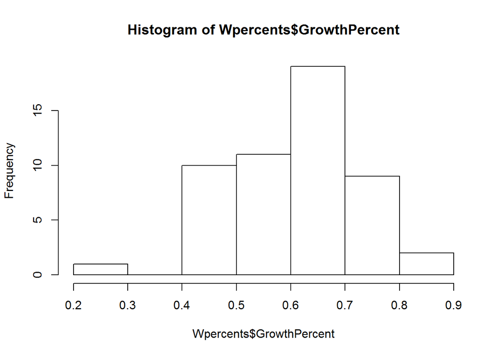

```r
WEHIcomplete <- WEHIonly %>% filter(!is.na(WellsGrown))
Wpercents <- WEHIcomplete %>% transform(GrowthPercent = WellsGrown / WellsPlated)
hist(Wpercents$GrowthPercent)
```

Which conditions gave the low end of the growth percent?

```r
Wlowgrowth <- Wpercents %>% filter(GrowthPercent < 0.4)
Wlowgrowth[1,c(1,5,6,9,10)]
```

```
##          LineID PlateSeries DaysPostInfection WellsPlated WellsGrown
## 1 6_P210_Fusion           6                 9          96         26
```

Comparing PE of cells plated at 2 days and 9 days post-infection

```r
Wpercents2 <- Wpercents %>% filter(DaysPostInfection == 2)
Wpercents9 <- Wpercents %>% filter(DaysPostInfection == 9)
summary(Wpercents2)
```

```
##                LineID   LineNum_legacy  Transgene       Mutation
##  1_CSF2RB_R461C   : 1   Min.   : 1.0   CSF2RB:6   243InsPPCL:3
##  1_CSF2RB_WT      : 1   1st Qu.: 7.5   CSF3R :9   Empty     :3
##  1_CSF3R_T618I    : 1   Median :15.0   IL7R  :6   Fusion    :3
##  1_CSF3R_W791X    : 1   Mean   :15.0   P210  :3   R461C     :3
##  1_CSF3R_WT       : 1   3rd Qu.:22.5   Vector:3   T618I     :3
##  1_IL7R_243InsPPCL: 1   Max.   :29.0              W791X     :3
##  (Other)          :21                             WT        :9
##   PlateSeries DaysPostInfection  CellsPerWell  Media     WellsPlated
##  Min.   :1    Min.   :2         Min.   :1     R10 : 0   Min.   :96
##  1st Qu.:1    1st Qu.:2         1st Qu.:1     WEHI:27   1st Qu.:96
##  Median :3    Median :2         Median :1               Median :96
##  Mean   :3    Mean   :2         Mean   :1               Mean   :96
##  3rd Qu.:5    3rd Qu.:2         3rd Qu.:1               3rd Qu.:96
##  Max.   :5    Max.   :2         Max.   :1               Max.   :96
##
##    WellsGrown    WellsCensored GrowthPercent
##  Min.   :42.00   Min.   :0     Min.   :0.4375
##  1st Qu.:50.00   1st Qu.:0     1st Qu.:0.5208
##  Median :61.00   Median :0     Median :0.6354
##  Mean   :58.93   Mean   :0     Mean   :0.6138
##  3rd Qu.:66.50   3rd Qu.:0     3rd Qu.:0.6927
##  Max.   :77.00   Max.   :0     Max.   :0.8021
##
```

```r
summary(Wpercents9)
```

```
##                LineID   LineNum_legacy   Transgene       Mutation
##  2_CSF2RB_R461C   : 1   Min.   : 1.00   CSF2RB:4   243InsPPCL:3
##  2_CSF2RB_WT      : 1   1st Qu.: 7.00   CSF3R :9   Empty     :3
##  2_CSF3R_T618I    : 1   Median :16.00   IL7R  :6   Fusion    :3
##  2_CSF3R_W791X    : 1   Mean   :15.28   P210  :3   R461C     :2
##  2_CSF3R_WT       : 1   3rd Qu.:23.00   Vector:3   T618I     :3
##  2_IL7R_243InsPPCL: 1   Max.   :29.00              W791X     :3
##  (Other)          :19                              WT        :8
##   PlateSeries DaysPostInfection  CellsPerWell  Media     WellsPlated
##  Min.   :2    Min.   :9         Min.   :1     R10 : 0   Min.   :96
##  1st Qu.:2    1st Qu.:9         1st Qu.:1     WEHI:25   1st Qu.:96
##  Median :4    Median :9         Median :1               Median :96
##  Mean   :4    Mean   :9         Mean   :1               Mean   :96
##  3rd Qu.:6    3rd Qu.:9         3rd Qu.:1               3rd Qu.:96
##  Max.   :6    Max.   :9         Max.   :1               Max.   :96
##
##    WellsGrown   WellsCensored GrowthPercent
##  Min.   :26.0   Min.   :0     Min.   :0.2708
##  1st Qu.:56.0   1st Qu.:0     1st Qu.:0.5833
##  Median :61.0   Median :0     Median :0.6354
##  Mean   :59.4   Mean   :0     Mean   :0.6188
##  3rd Qu.:67.0   3rd Qu.:0     3rd Qu.:0.6979
##  Max.   :77.0   Max.   :0     Max.   :0.8021
##
```

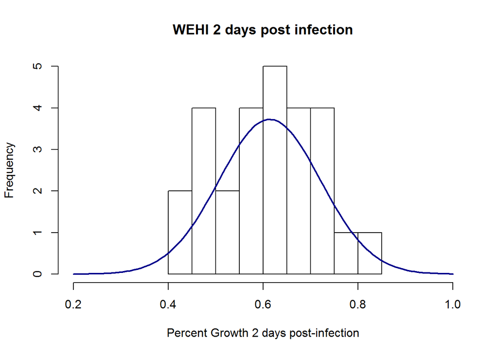

```r
hist(Wpercents2$GrowthPercent, xlim = c(0.2,1), xlab = "Percent Growth 2 days post-infection", breaks = 8, main = "WEHI 2 days post infection")
curve(dnorm(x, mean = mean(Wpercents2$GrowthPercent), sd = sd(Wpercents2$GrowthPercent)), add = TRUE, col = "darkblue", lwd = 2)
```

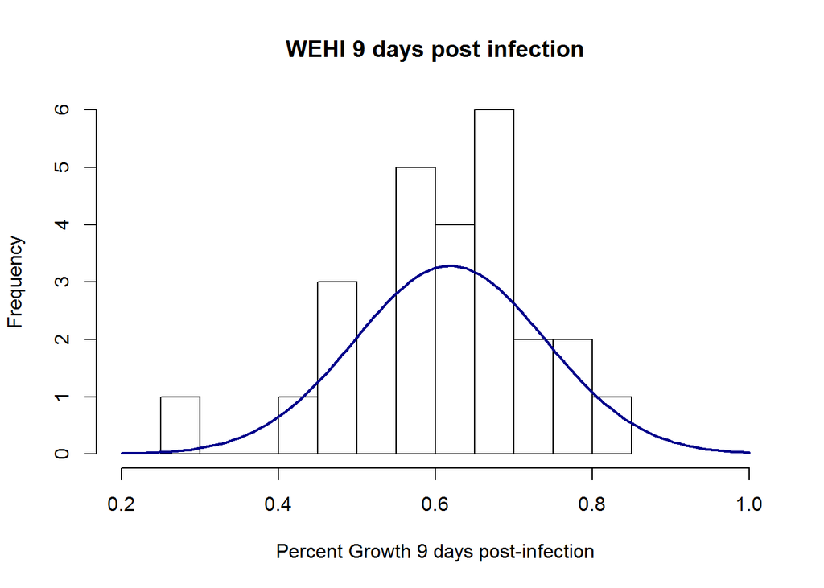

```r
hist(Wpercents9$GrowthPercent, xlim = c(0.2,1), xlab = "Percent Growth 9 days post-infection", breaks = 8, main = "WEHI 9 days post infection")
curve(dnorm(x, mean = mean(Wpercents9$GrowthPercent), sd = sd(Wpercents9$GrowthPercent)), add = TRUE, col = "darkblue", lwd = 2)
```

### **Conclusion: days post-infection do not seem to impact plating efficiency**

Let’s try the same approach with the R10 data

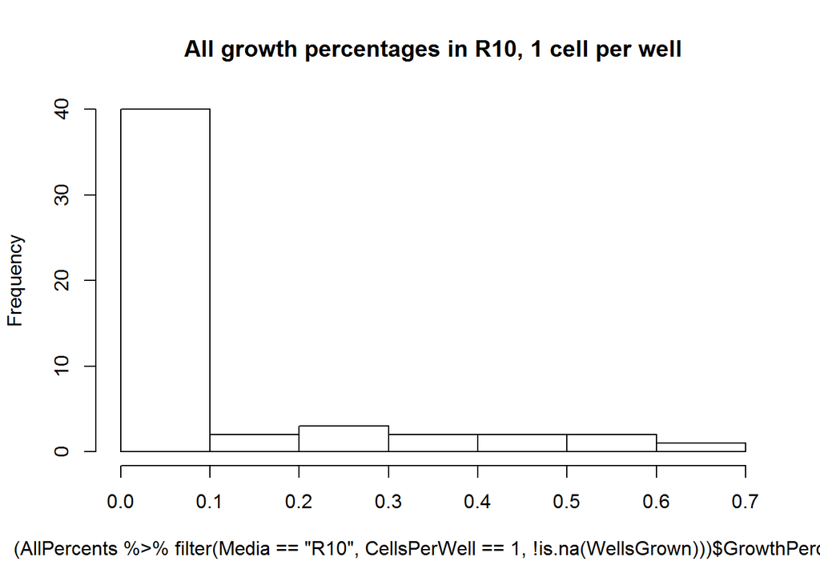

```r
AllPercents <- RawData %>% mutate(GrowthPercent = WellsGrown / WellsPlated)
hist((AllPercents %>% filter(Media == "R10", CellsPerWell == 1, !is.na(WellsGrown)))$GrowthPercent, main = "All growth percentages in R10, 1 cell per well")
```

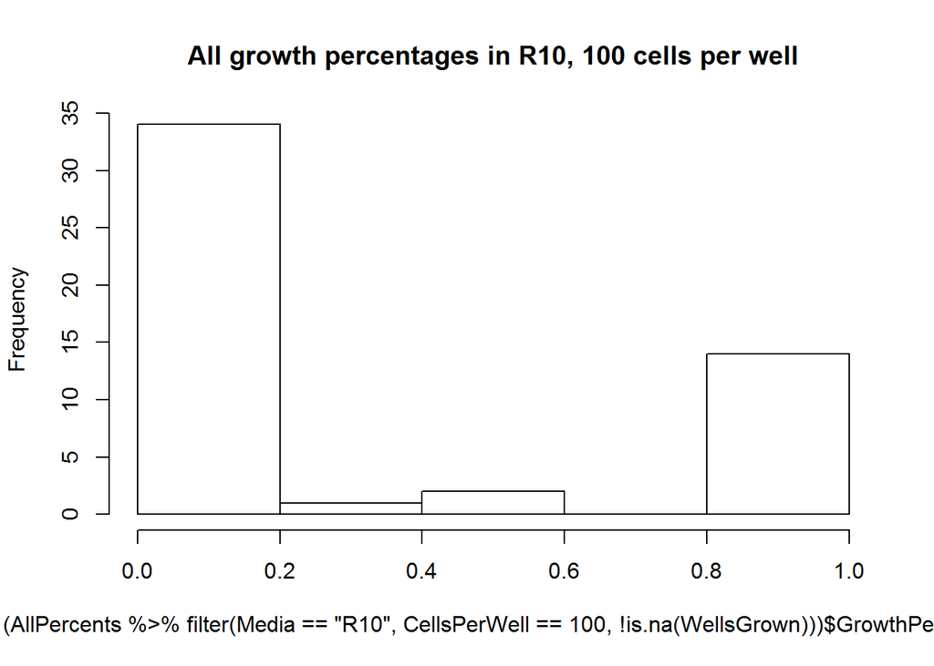

```r
hist((AllPercents %>% filter(Media == "R10", CellsPerWell == 100, !is.na(WellsGrown)))$GrowthPercent, main = "All growth percentages in R10, 100 cells per well")
```

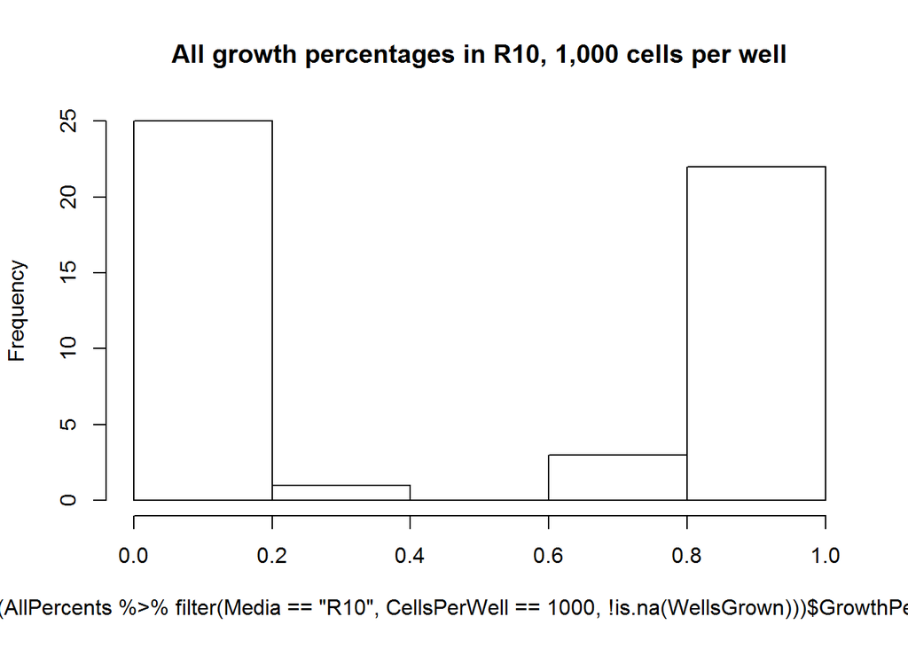

```r
hist((AllPercents %>% filter(Media == "R10", CellsPerWell == 1000, !is.na(WellsGrown)))$GrowthPercent, main = "All growth percentages in R10, 1,000 cells per well")
```

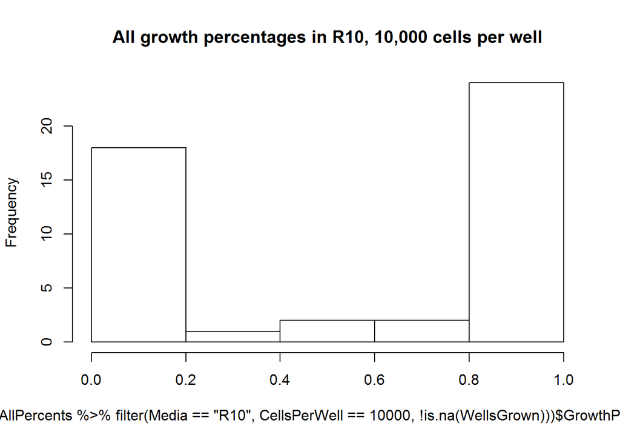

```r
hist((AllPercents %>% filter(Media == "R10", CellsPerWell == 10000, !is.na(WellsGrown)))$GrowthPercent, main = "All growth percentages in R10, 10,000 cells per well")
```

For starters, we need to accomplish three points: 1. We need to adjust WellsPlated for Censored 2. We need to calculate GrowthPercent for all observations 3. We need to adjust GrowthPercent for Plating Effiency

```r
CompleteData <- RawData %>% filter(!is.na(WellsPlated))
CompleteData <- CompleteData %>% mutate(TrueWellsPlated = WellsPlated - WellsCensored)
CompleteData <- CompleteData %>% select(-WellsPlated, -WellsCensored)
head(CompleteData)
```

```
##        LineID LineNum_legacy Transgene Mutation PlateSeries
## 1 1_CSF2RB_WT              1    CSF2RB       WT           1
## 2 1_CSF2RB_WT              1    CSF2RB       WT           1
## 3 1_CSF2RB_WT              1    CSF2RB       WT           1
## 4 1_CSF2RB_WT              1    CSF2RB       WT           1
## 5 1_CSF2RB_WT              1    CSF2RB       WT           1
## 6 2_CSF2RB_WT              1    CSF2RB       WT           2
##   DaysPostInfection CellsPerWell Media WellsGrown TrueWellsPlated
## 1                 2            1  WEHI         66              96
## 2                 2            1   R10          0              96
## 3                 2          100   R10          0              24
## 4                 2         1000   R10          0              24
## 5                 2        10000   R10          1              48
## 6                 9            1  WEHI         67              96
```

```r
CompleteData <- CompleteData %>% mutate(LineID = str_sub(LineID, 2)) %>% mutate(LineID = paste(LineNum_legacy, LineID, sep = ""))
head(CompleteData)
```

```
##        LineID LineNum_legacy Transgene Mutation PlateSeries
## 1 1_CSF2RB_WT              1    CSF2RB       WT           1
## 2 1_CSF2RB_WT              1    CSF2RB       WT           1
## 3 1_CSF2RB_WT              1    CSF2RB       WT           1
## 4 1_CSF2RB_WT              1    CSF2RB       WT           1
## 5 1_CSF2RB_WT              1    CSF2RB       WT           1
## 6 1_CSF2RB_WT              1    CSF2RB       WT           2
##   DaysPostInfection CellsPerWell Media WellsGrown TrueWellsPlated
## 1                 2            1  WEHI         66              96
## 2                 2            1   R10          0              96
## 3                 2          100   R10          0              24
## 4                 2         1000   R10          0              24
## 5                 2        10000   R10          1              48
## 6                 9            1  WEHI         67              96
```

```r
CompletePercent <- CompleteData %>% mutate(GrowthPercent = WellsGrown / TrueWellsPlated) %>% select(-WellsGrown, -TrueWellsPlated, -LineNum_legacy, -Transgene, -Mutation)
head(CompletePercent)
```

```
##        LineID PlateSeries DaysPostInfection CellsPerWell Media
## 1 1_CSF2RB_WT           1                 2            1  WEHI
## 2 1_CSF2RB_WT           1                 2            1   R10
## 3 1_CSF2RB_WT           1                 2          100   R10
## 4 1_CSF2RB_WT           1                 2         1000   R10
## 5 1_CSF2RB_WT           1                 2        10000   R10
## 6 1_CSF2RB_WT           2                 9            1  WEHI
##   GrowthPercent
## 1    0.68750000
## 2    0.00000000
## 3    0.00000000
## 4    0.00000000
## 5    0.02083333
## 6    0.69791667
```

Trying to reshape data to allow for better analysis

```r
#Change Media type to a single letter
CompletePercent <- CompletePercent %>% mutate(Media = str_sub(Media,1,1))
#Concatenate some identifiers into a single field, then drop unused columns
CompleteConcat <- CompletePercent %>% mutate(Media_Day_Cells = paste(Media, DaysPostInfection, CellsPerWell, sep = "_")) %>% select(-PlateSeries, -DaysPostInfection, -CellsPerWell, -Media)
#Change the identifier column into a factor (instead of character)
CompleteConcat <- CompleteConcat %>% mutate(Media_Day_Cells = as.factor(Media_Day_Cells))
head(CompleteConcat)
```

```
##        LineID GrowthPercent Media_Day_Cells
## 1 1_CSF2RB_WT    0.68750000           W_2_1
## 2 1_CSF2RB_WT    0.00000000           R_2_1
## 3 1_CSF2RB_WT    0.00000000         R_2_100
## 4 1_CSF2RB_WT    0.00000000        R_2_1000
## 5 1_CSF2RB_WT    0.02083333       R_2_10000
## 6 1_CSF2RB_WT    0.69791667           W_9_1
```

```r
#Recast the data with LineID as the rows, Media_Day_Cells as the columns, and GrowthPercent as the values
CompleteTidy <- recast(CompleteConcat, LineID ~ Media_Day_Cells, id.var = c("LineID","Media_Day_Cells"), fun.aggregate = mean, na.rm = TRUE)
head(CompleteTidy)
```

```
##            LineID   R_2_1 R_2_100  R_2_1000  R_2_10000      R_9_1
## 1     1_CSF2RB_WT 0.00000   0.000 0.0000000 0.02083333 0.00000000
## 2    11_CSF2RB_WT 0.00000     NaN       NaN        NaN        NaN
## 3 12_CSF2RB_R461C 0.00000   0.000 0.0000000 0.28260870        NaN
## 4     13_CSF3R_WT 0.00000   0.125 0.8750000 1.00000000 0.00000000
## 5  14_CSF3R_T618I 0.34375   1.000 1.0000000 1.00000000 0.50000000
## 6  15_CSF3R_W791X 0.00000   0.125 0.7916667 1.00000000 0.01041667
##     R_9_100 R_9_1000 R_9_10000     W_2_1     W_9_1
## 1 0.0000000    0.000         0 0.6875000 0.6979167
## 2       NaN      NaN       NaN 0.6354167       NaN
## 3       NaN      NaN       NaN 0.5833333       NaN
## 4 0.2500000    0.875         1 0.7187500 0.5937500
## 5 1.0000000    1.000         1 0.4375000 0.4895833
## 6 0.4583333    1.000         1 0.6458333 0.7708333
```

```r
#Output the results
#write.csv(CompleteTidy, file = "CompleteTidy.csv")
```

Going to do some scatter plots to look for covariance between PE on day2 and day9 samples

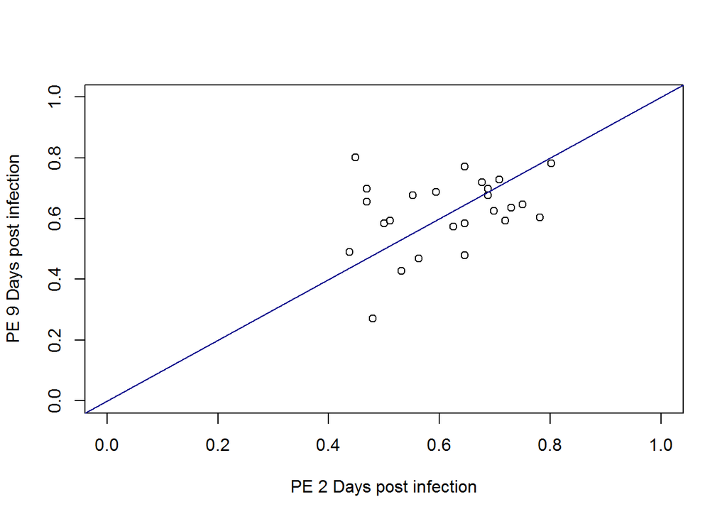

```r
plot(CompleteTidy$`W_2_1`, CompleteTidy$`W_9_1`, xlab = "PE 2 Days post infection", ylab = "PE 9 Days post infection", xlim = 0:1, ylim = 0:1)
abline(a = 0, b = 1, col = "darkblue")
```

The PE of cell lines cluster, but not super related (IMO) which is expected. ## Adjusting Growth Percentage for Plating Efficiency

```r
summary(CompleteTidy)
```

```
##     LineID              R_2_1            R_2_100          R_2_1000
##  Length:27          Min.   :0.00000   Min.   :0.0000   Min.   :0.00000
##  Class :character   1st Qu.:0.00000   1st Qu.:0.0000   1st Qu.:0.00000
##  Mode  :character   Median :0.00000   Median :0.0000   Median :0.04167
##                     Mean   :0.08410   Mean   :0.3013   Mean   :0.44071
##                     3rd Qu.:0.03125   3rd Qu.:0.7917   3rd Qu.:1.00000
##                     Max.   :0.63542   Max.   :1.0000   Max.   :1.00000
##                                       NA's   :1        NA's   :1
##    R_2_10000           R_9_1            R_9_100          R_9_1000
##  Min.   :0.00000   Min.   :0.00000   Min.   :0.0000   Min.   :0.000
##  1st Qu.:0.02083   1st Qu.:0.00000   1st Qu.:0.0000   1st Qu.:0.000
##  Median :0.57654   Median :0.00000   Median :0.0000   Median :0.625
##  Mean   :0.52460   Mean   :0.09417   Mean   :0.3200   Mean   :0.510
##  3rd Qu.:1.00000   3rd Qu.:0.01042   3rd Qu.:0.9167   3rd Qu.:1.000
##  Max.   :1.00000   Max.   :0.57292   Max.   :1.0000   Max.   :1.000
##  NA's   :5         NA's   :2         NA's   :2        NA's   :2
##    R_9_10000          W_2_1            W_9_1
##  Min.   :0.0000   Min.   :0.4375   Min.   :0.2708
##  1st Qu.:0.0000   1st Qu.:0.5208   1st Qu.:0.5833
##  Median :1.0000   Median :0.6354   Median :0.6354
##  Mean   :0.6183   Mean   :0.6138   Mean   :0.6188
##  3rd Qu.:1.0000   3rd Qu.:0.6927   3rd Qu.:0.6979
##  Max.   :1.0000   Max.   :0.8021   Max.   :0.8021
##  NA's   :2                         NA's   :2
```

```r
CompleteTidy <- CompleteTidy %>% mutate(R_2_1 = R_2_1 / W_2_1)
summary(CompleteTidy)
```

```
##     LineID              R_2_1            R_2_100          R_2_1000
##  Length:27          Min.   :0.00000   Min.   :0.0000   Min.   :0.00000
##  Class :character   1st Qu.:0.00000   1st Qu.:0.0000   1st Qu.:0.00000
##  Mode  :character   Median :0.00000   Median :0.0000   Median :0.04167
##                     Mean   :0.14673   Mean   :0.3013   Mean   :0.44071
##                     3rd Qu.:0.05573   3rd Qu.:0.7917   3rd Qu.:1.00000
##                     Max.   :0.88710   Max.   :1.0000   Max.   :1.00000
##                                       NA's   :1        NA's   :1
##    R_2_10000           R_9_1            R_9_100          R_9_1000
##  Min.   :0.00000   Min.   :0.00000   Min.   :0.0000   Min.   :0.000
##  1st Qu.:0.02083   1st Qu.:0.00000   1st Qu.:0.0000   1st Qu.:0.000
##  Median :0.57654   Median :0.00000   Median :0.0000   Median :0.625
##  Mean   :0.52460   Mean   :0.09417   Mean   :0.3200   Mean   :0.510
##  3rd Qu.:1.00000   3rd Qu.:0.01042   3rd Qu.:0.9167   3rd Qu.:1.000
##  Max.   :1.00000   Max.   :0.57292   Max.   :1.0000   Max.   :1.000
##  NA's   :5         NA's   :2         NA's   :2        NA's   :2
##    R_9_10000          W_2_1            W_9_1
##  Min.   :0.0000   Min.   :0.4375   Min.   :0.2708
##  1st Qu.:0.0000   1st Qu.:0.5208   1st Qu.:0.5833
##  Median :1.0000   Median :0.6354   Median :0.6354
##  Mean   :0.6183   Mean   :0.6138   Mean   :0.6188
##  3rd Qu.:1.0000   3rd Qu.:0.6927   3rd Qu.:0.6979
##  Max.   :1.0000   Max.   :0.8021   Max.   :0.8021
##  NA's   :2                         NA's   :2
```

## Installed statmod to use ELDA/limdil functions

```r
library(statmod)
```

Important considerations:  
Observed = FALSE - indicates that we are dealing with a Poisson distribution, not a direct observation and confirmation of the plated cell number

ELDA doesn’t seem to be taking into account Plating Efficiency, so we might have to do that on our own, adjusting the “plated” number accordingly

**Going back to more raw dataset to undo some transformations**

```r
CompleteData <- CompleteData %>% mutate(LineID = paste(LineID, DaysPostInfection, sep = "_"))
head(CompleteData)
```

```
##          LineID LineNum_legacy Transgene Mutation PlateSeries
## 1 1_CSF2RB_WT_2              1    CSF2RB       WT           1
## 2 1_CSF2RB_WT_2              1    CSF2RB       WT           1
## 3 1_CSF2RB_WT_2              1    CSF2RB       WT           1
## 4 1_CSF2RB_WT_2              1    CSF2RB       WT           1
## 5 1_CSF2RB_WT_2              1    CSF2RB       WT           1
## 6 1_CSF2RB_WT_9              1    CSF2RB       WT           2
##   DaysPostInfection CellsPerWell Media WellsGrown TrueWellsPlated
## 1                 2            1  WEHI         66              96
## 2                 2            1   R10          0              96
## 3                 2          100   R10          0              24
## 4                 2         1000   R10          0              24
## 5                 2        10000   R10          1              48
## 6                 9            1  WEHI         67              96
```

Need to calculate PE for each Line + Plate series and add to all rows

```r
WehiPE <- CompleteData %>% filter(Media == "WEHI")
head(WehiPE)
```

```
##             LineID LineNum_legacy Transgene Mutation PlateSeries
## 1    1_CSF2RB_WT_2              1    CSF2RB       WT           1
## 2    1_CSF2RB_WT_9              1    CSF2RB       WT           2
## 3 2_CSF2RB_R461C_2              2    CSF2RB    R461C           1
## 4 2_CSF2RB_R461C_9              2    CSF2RB    R461C           2
## 5     3_CSF3R_WT_2              3     CSF3R       WT           1
## 6     3_CSF3R_WT_9              3     CSF3R       WT           2
##   DaysPostInfection CellsPerWell Media WellsGrown TrueWellsPlated
## 1                 2            1  WEHI         66              96
## 2                 9            1  WEHI         67              96
## 3                 2            1  WEHI         45              96
## 4                 9            1  WEHI         63              96
## 5                 2            1  WEHI         68              96
## 6                 9            1  WEHI         70              96
```

```r
##THIS IS THE WRONG WAY TO CALCULATE PE!!! Doesn't assume Poisson distribution
#WehiPE <- WehiPE %>% mutate(PE = WellsGrown / TrueWellsPlated)
#head(WehiPE)

WehiELDA <- elda(response = WehiPE$WellsGrown, dose = WehiPE$CellsPerWell, tested = WehiPE$TrueWellsPlated, group = WehiPE$LineID, observed = FALSE, confidence = 0.95, test.unit.slope = TRUE)
WehiELDAest <- as.data.frame(WehiELDA$CI)
head(WehiELDA)
```

```
## $response
##  [1] 66 67 45 63 68 70 51 41 62 56 77 75 66 65 57 66 49 57 61 56 69 57 42
## [24] 47 62 74 45 67 60 55 67 60 70 61 72 62 65 69 53 65 62 46 75 58 48 56
## [47] 54 45 43 77 46 26
##
## $tested
##  [1] 96 96 96 96 96 96 96 96 96 96 96 96 96 96 96 96 96 96 96 96 96 96 96
## [24] 96 96 96 96 96 96 96 96 96 96 96 96 96 96 96 96 96 96 96 96 96 96 96
## [47] 96 96 96 96 96 96
##
## $dose
##  [1] 1 1 1 1 1 1 1 1 1 1 1 1 1 1 1 1 1 1 1 1 1 1 1 1 1 1 1 1 1 1 1 1 1 1 1
## [36] 1 1 1 1 1 1 1 1 1 1 1 1 1 1 1 1 1
##
## $group
##  [1] 1_CSF2RB_WT_2        1_CSF2RB_WT_9        2_CSF2RB_R461C_2
##  [4] 2_CSF2RB_R461C_9     3_CSF3R_WT_2         3_CSF3R_WT_9
##  [7] 4_CSF3R_T618I_2      4_CSF3R_T618I_9      5_CSF3R_W791X_2
## [10] 5_CSF3R_W791X_9      6_IL7R_WT_2          6_IL7R_WT_9
## [13] 7_IL7R_243InsPPCL_2  7_IL7R_243InsPPCL_9  8_Vector_Empty_2
## [16] 8_Vector_Empty_9     9_P210_Fusion_2      9_P210_Fusion_9
## [19] 11_CSF2RB_WT_2       12_CSF2RB_R461C_2    13_CSF3R_WT_2
## [22] 13_CSF3R_WT_9        14_CSF3R_T618I_2     14_CSF3R_T618I_9
## [25] 15_CSF3R_W791X_2     15_CSF3R_W791X_9     16_IL7R_WT_2
## [28] 16_IL7R_WT_9         17_IL7R_243InsPPCL_2 17_IL7R_243InsPPCL_9
## [31] 18_Vector_Empty_2    18_Vector_Empty_9    19_P210_Fusion_2
## [34] 19_P210_Fusion_9     21_CSF2RB_WT_2       21_CSF2RB_WT_9
## [37] 22_CSF2RB_R461C_2    22_CSF2RB_R461C_9    23_CSF3R_WT_2
## [40] 23_CSF3R_WT_9        24_CSF3R_T618I_2     24_CSF3R_T618I_9
## [43] 25_CSF3R_W791X_2     25_CSF3R_W791X_9     26_IL7R_WT_2
## [46] 26_IL7R_WT_9         27_IL7R_243InsPPCL_2 27_IL7R_243InsPPCL_9
## [49] 28_Vector_Empty_2    28_Vector_Empty_9    29_P210_Fusion_2
## [52] 29_P210_Fusion_9
## 52 Levels: 1_CSF2RB_WT_2 1_CSF2RB_WT_9 ... 9_P210_Fusion_9
##
## $num.group
## [1] 52
##
## $CI
##                               Lower Estimate    Upper
```

[output cut: 37 more lines]

```
## Group 29_P210_Fusion_9     4.657407 3.166030 2.152216
## Group 3_CSF3R_WT_2         1.045242 1.000000 1.000000
## Group 3_CSF3R_WT_9         1.000000 1.000000 1.000000
## Group 4_CSF3R_T618I_2      1.748134 1.319808 1.000000
## Group 4_CSF3R_T618I_9      2.447900 1.795284 1.316657
## Group 5_CSF3R_W791X_2      1.249768 1.000000 1.000000
## Group 5_CSF3R_W791X_9      1.496833 1.142245 1.000000
## Group 6_IL7R_WT_2          1.000000 1.000000 1.000000
## Group 6_IL7R_WT_9          1.000000 1.000000 1.000000
## Group 7_IL7R_243InsPPCL_2  1.109550 1.000000 1.000000
## Group 7_IL7R_243InsPPCL_9  1.143070 1.000000 1.000000
## Group 8_Vector_Empty_2     1.452022 1.110141 1.000000
## Group 8_Vector_Empty_9     1.109550 1.000000 1.000000
## Group 9_P210_Fusion_2      1.863721 1.400167 1.051910
## Group 9_P210_Fusion_9      1.452022 1.110141 1.000000
```

```r
WehiELDAest <- add_rownames(WehiELDAest, var = "LineID")
WehiELDAest <- WehiELDAest %>% mutate(LineID = as.factor(LineID))
#write.csv(WehiELDAest, "WehiELDAConfIntervals.csv")

#Drop Observations 11 and 12, incomplete due to contam
WehiELDAest <- WehiELDAest[c(-3,-4),]
head(WehiELDAest)
```

```
## Source: local data frame [6 x 4]
##
##                   LineID    Lower Estimate    Upper
##                   (fctr)    (dbl)    (dbl)    (dbl)
## 1    Group 1_CSF2RB_WT_2 1.109550 1.000000 1.000000
## 2    Group 1_CSF2RB_WT_9 1.076958 1.000000 1.000000
## 3    Group 13_CSF3R_WT_2 1.014351 1.000000 1.000000
## 4    Group 13_CSF3R_WT_9 1.452022 1.110141 1.000000
## 5 Group 14_CSF3R_T618I_2 2.361672 1.738030 1.279071
## 6 Group 14_CSF3R_T618I_9 1.989772 1.486927 1.111159
```

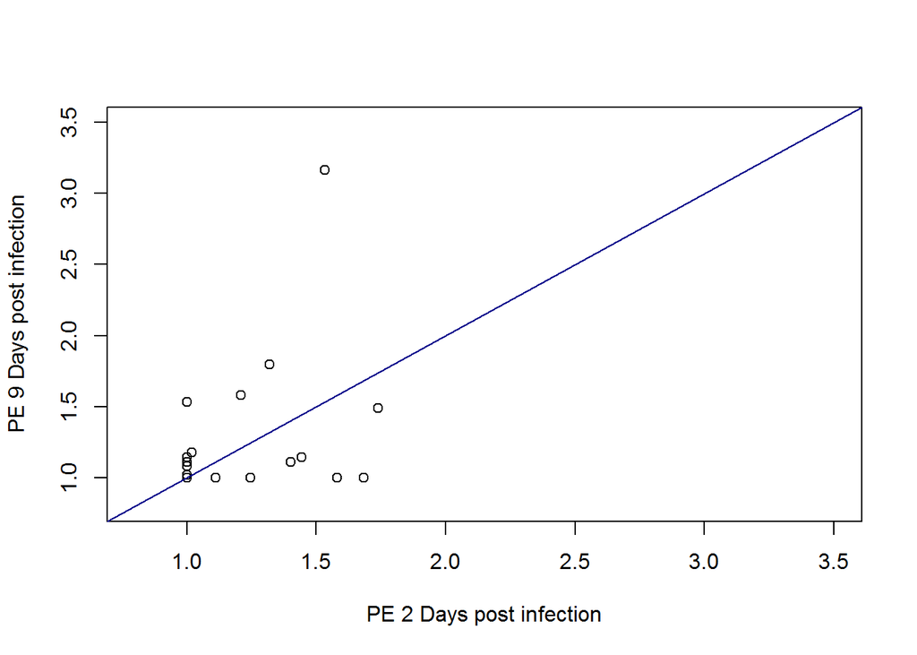

```r
Odd <- seq(1,50,2)
Even <- seq(2,50,2)
PE2d <- WehiELDAest[Odd,3]
PE9d <- WehiELDAest[Even,3]
plot(PE2d$Estimate, PE9d$Estimate, xlab = "PE 2 Days post infection", ylab = "PE 9 Days post infection", xlim = c(0.8,3.5), ylim = c(0.8,3.5))
abline(a = 0, b = 1, col = "darkblue")
```

```r
#Need to clean up the LineID field
WehiELDAest <- WehiELDAest %>% mutate(LineID = as.character(LineID))
WehiELDAest$LineID <- substr(WehiELDAest$LineID,7,nchar(WehiELDAest$LineID))


PEonly <- WehiELDAest %>% select(LineID, Estimate)
head(PEonly)
```

```
## Source: local data frame [6 x 2]
##
##             LineID Estimate
##              (chr)    (dbl)
## 1    1_CSF2RB_WT_2 1.000000
## 2    1_CSF2RB_WT_9 1.000000
## 3    13_CSF3R_WT_2 1.000000
## 4    13_CSF3R_WT_9 1.110141
## 5 14_CSF3R_T618I_2 1.738030
## 6 14_CSF3R_T618I_9 1.486927
```

```r
R10only <- CompleteData %>% filter(Media == "R10")
R10PE <- merge(R10only, PEonly, by="LineID")
head(R10PE)
```

```
##          LineID LineNum_legacy Transgene Mutation PlateSeries
## 1 1_CSF2RB_WT_2              1    CSF2RB       WT           1
## 2 1_CSF2RB_WT_2              1    CSF2RB       WT           1
## 3 1_CSF2RB_WT_2              1    CSF2RB       WT           1
## 4 1_CSF2RB_WT_2              1    CSF2RB       WT           1
## 5 1_CSF2RB_WT_9              1    CSF2RB       WT           2
## 6 1_CSF2RB_WT_9              1    CSF2RB       WT           2
##   DaysPostInfection CellsPerWell Media WellsGrown TrueWellsPlated Estimate
## 1                 2          100   R10          0              24        1
## 2                 2         1000   R10          0              24        1
## 3                 2        10000   R10          1              48        1
## 4                 2            1   R10          0              96        1
## 5                 9            1   R10          0              96        1
## 6                 9          100   R10          0              24        1
```

Adjust Cells per Well by PE

```r
TidyData <- R10PE %>% mutate(PE_adjusted_cells = CellsPerWell / Estimate)
head(TidyData)
```

```
##          LineID LineNum_legacy Transgene Mutation PlateSeries
## 1 1_CSF2RB_WT_2              1    CSF2RB       WT           1
## 2 1_CSF2RB_WT_2              1    CSF2RB       WT           1
## 3 1_CSF2RB_WT_2              1    CSF2RB       WT           1
## 4 1_CSF2RB_WT_2              1    CSF2RB       WT           1
## 5 1_CSF2RB_WT_9              1    CSF2RB       WT           2
## 6 1_CSF2RB_WT_9              1    CSF2RB       WT           2
##   DaysPostInfection CellsPerWell Media WellsGrown TrueWellsPlated Estimate
## 1                 2          100   R10          0              24        1
## 2                 2         1000   R10          0              24        1
## 3                 2        10000   R10          1              48        1
## 4                 2            1   R10          0              96        1
## 5                 9            1   R10          0              96        1
## 6                 9          100   R10          0              24        1
##   PE_adjusted_cells
## 1               100
## 2              1000
## 3             10000
## 4                 1
## 5                 1
## 6               100
```

```r
#write.csv(TidyData, file = "TidyData.csv")
```

Drop Samples 11 and 12 - Incomplete data due to plate contamination

```r
dim(TidyData)
```

```
## [1] 196  12
```

```r
TidyData <- TidyData %>% filter(!LineNum_legacy == 11) %>% filter(!LineNum_legacy == 12)
dim(TidyData)
```

```
## [1] 196  12
```

Trial ELDA for 22_CSF2RB_R461C_2

```r
Trial <- TidyData %>% filter(LineNum_legacy == "22")
Trialout <- elda(Trial$WellsGrown, Trial$PE_adjusted_cells, Trial$TrueWellsPlated, Trial$LineID, observed = FALSE, confidence = 0.95, test.unit.slope = TRUE)
plot(Trialout)
Trialout
```

```
## Confidence intervals for frequency:
##
##                             Lower Estimate    Upper
## Group 22_CSF2RB_R461C_2  23673.57 15788.82 10530.18
## Group 22_CSF2RB_R461C_9 117774.42 58750.27 29306.83
##
## Differences between groups:
## Chisq 12.0388 on 1 DF, p-value: 0.000521
##
## Goodness of fit (test log-Dose slope equals 1):
##                       Estimate Std. Error  z value Pr(>|z|)
## Wald test               1.0548    0.29116 0.188233   0.8507
## LR test                     NA         NA 0.193460   0.8466
## Score test: log(Dose)       NA         NA 0.188862   0.8502
## Score test: Dose            NA         NA 0.077316   0.9384
```

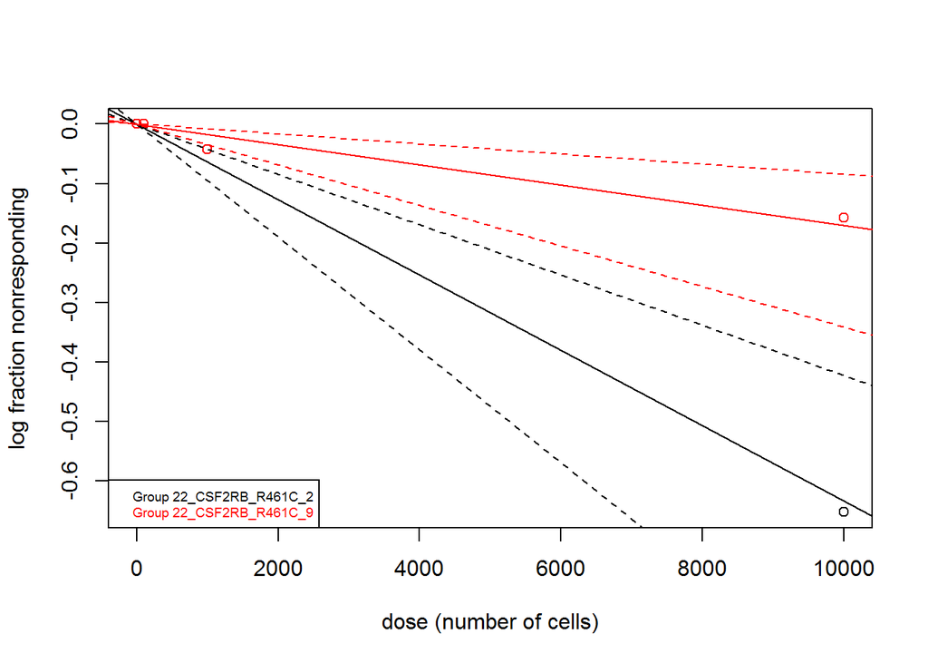

```r
#See if I can't clean up this code
Trialout2 <- elda(response = Trial$WellsGrown, dose = Trial$PE_adjusted_cells, tested = Trial$TrueWellsPlated, group = Trial$LineID, observed = FALSE, confidence = 0.95, test.unit.slope = TRUE)
plot(Trialout2)
```

Massive ELDA

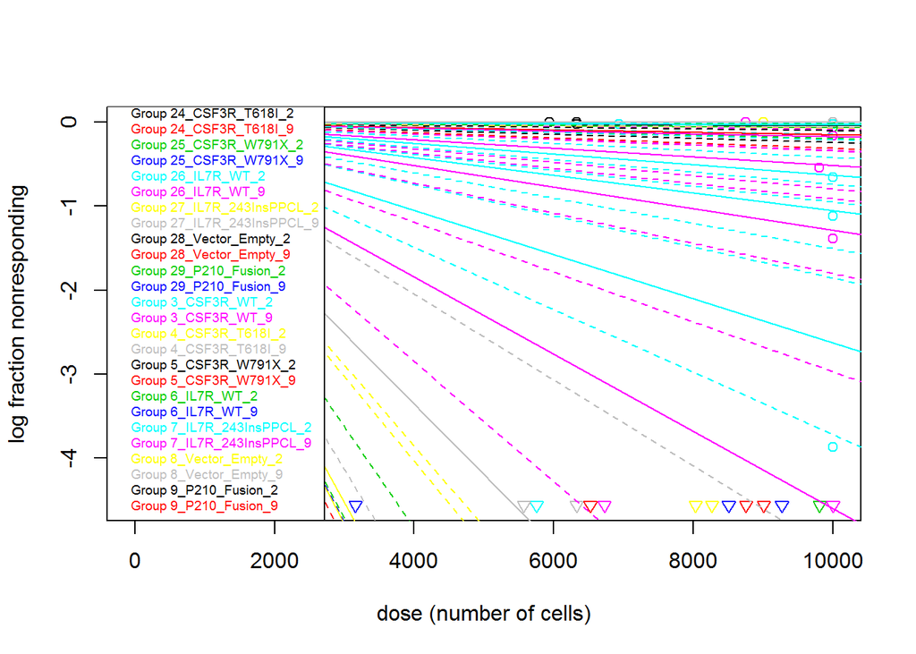

```r
MassELDA <- elda(response = TidyData$WellsGrown, dose = TidyData$PE_adjusted_cells, tested = TidyData$TrueWellsPlated, group = TidyData$LineID, observed = FALSE, confidence = 0.95, test.unit.slope = TRUE)
plot(MassELDA)
```

```r
ELDACI <- as.data.frame(MassELDA$CI)

head(ELDACI)
```

```
##                               Lower     Estimate       Upper
## Group 1_CSF2RB_WT_2    3.558491e+06 5.014794e+05  70670.8524
## Group 1_CSF2RB_WT_9             Inf          Inf 169072.5184
## Group 13_CSF3R_WT_2    8.255687e+02 5.300031e+02    340.2543
## Group 13_CSF3R_WT_9    6.281102e+02 4.023281e+02    257.7062
## Group 14_CSF3R_T618I_2 1.926254e+00 1.365968e+00      1.0000
## Group 14_CSF3R_T618I_9 1.294850e+00 1.000000e+00      1.0000
```

```r
ELDACI <- add_rownames(ELDACI, var = "LineID")
ELDACI <- ELDACI %>% mutate(LineID = as.character(LineID))
#write.csv(MassELDA$CI, "ELDAConfIntervals.csv")
##These lines below aren't running, but I also don't need them, not sure if they ever worked
#TidyELDA <- merge(TidyData, ELDACI, by=1)
#head(TidyELDA)
```

Try to bin all runs together for ELDA

```r
TidyBin <- TidyData %>% mutate(Gene = paste(Transgene, Mutation, sep = "_"))
head(TidyBin)
```

```
##          LineID LineNum_legacy Transgene Mutation PlateSeries
## 1 1_CSF2RB_WT_2              1    CSF2RB       WT           1
## 2 1_CSF2RB_WT_2              1    CSF2RB       WT           1
## 3 1_CSF2RB_WT_2              1    CSF2RB       WT           1
## 4 1_CSF2RB_WT_2              1    CSF2RB       WT           1
## 5 1_CSF2RB_WT_9              1    CSF2RB       WT           2
## 6 1_CSF2RB_WT_9              1    CSF2RB       WT           2
##   DaysPostInfection CellsPerWell Media WellsGrown TrueWellsPlated Estimate
## 1                 2          100   R10          0              24        1
## 2                 2         1000   R10          0              24        1
## 3                 2        10000   R10          1              48        1
## 4                 2            1   R10          0              96        1
## 5                 9            1   R10          0              96        1
## 6                 9          100   R10          0              24        1
##   PE_adjusted_cells      Gene
## 1               100 CSF2RB_WT
## 2              1000 CSF2RB_WT
## 3             10000 CSF2RB_WT
## 4                 1 CSF2RB_WT
## 5                 1 CSF2RB_WT
## 6               100 CSF2RB_WT
```

```r
BinELDA <- elda(response = TidyBin$WellsGrown, dose = TidyBin$PE_adjusted_cells, tested = TidyBin$TrueWellsPlated, group = TidyBin$Gene, observed = FALSE, confidence = 0.95, test.unit.slope = TRUE)
BinCI <- as.data.frame(BinELDA$CI) %>% add_rownames(var = "LineID") %>% mutate(LineID = as.factor(LineID))
#write.csv(BinCI, "BinnedELDACI.csv")
```

Bin together technical replicates (day 2 and day 9 samples)

```r
TidyBin2 <- TidyData %>% mutate(Gene = paste(Transgene, Mutation, LineNum_legacy, sep = "_"))
head(TidyBin2)
```

```
##          LineID LineNum_legacy Transgene Mutation PlateSeries
## 1 1_CSF2RB_WT_2              1    CSF2RB       WT           1
## 2 1_CSF2RB_WT_2              1    CSF2RB       WT           1
## 3 1_CSF2RB_WT_2              1    CSF2RB       WT           1
## 4 1_CSF2RB_WT_2              1    CSF2RB       WT           1
## 5 1_CSF2RB_WT_9              1    CSF2RB       WT           2
## 6 1_CSF2RB_WT_9              1    CSF2RB       WT           2
##   DaysPostInfection CellsPerWell Media WellsGrown TrueWellsPlated Estimate
## 1                 2          100   R10          0              24        1
## 2                 2         1000   R10          0              24        1
## 3                 2        10000   R10          1              48        1
## 4                 2            1   R10          0              96        1
## 5                 9            1   R10          0              96        1
## 6                 9          100   R10          0              24        1
##   PE_adjusted_cells        Gene
## 1               100 CSF2RB_WT_1
## 2              1000 CSF2RB_WT_1
## 3             10000 CSF2RB_WT_1
## 4                 1 CSF2RB_WT_1
## 5                 1 CSF2RB_WT_1
## 6               100 CSF2RB_WT_1
```

```r
Bin2ELDA <- elda(response = TidyBin2$WellsGrown, dose = TidyBin2$PE_adjusted_cells, tested = TidyBin2$TrueWellsPlated, group = TidyBin2$Gene, observed = FALSE, confidence = 0.95, test.unit.slope = TRUE)
Bin2CI <- as.data.frame(Bin2ELDA$CI) %>% add_rownames(var = "LineID") %>% mutate(LineID = as.factor(LineID))
#write.csv(Bin2CI, "BinnedELDACI_3bins.csv")
```